# Tsibble Exercise

Maren Rieker & Kabir Sandrolini

11/1/2021

## Retrieving Data

In this example, we use a data set from the tsibbledata package, nyc_bikes (https://github.com/tidyverts/tsibbledata). nyc_bikes contains information on trips taken in 2018 using NYC rental bikes. The bike_id helps to uniquely identify each observation, and the start_time serves as the index. It is an **irregular** tsibble, because bike rentals occur at different time intervals.

As a first step, please assign the data frame to an object and check its format.

```r
example <- nyc_bikes
example
```

```
## # A tsibble: 4,268 x 12 [!] <America/New_York>
## # Key:       bike_id [10]
##    bike_id start_time          stop_time           start_station start_lat
##    <fct>   <dttm>              <dttm>              <fct>             <dbl>
##  1 26301   2018-02-26 19:11:03 2018-02-26 19:15:40 3186               40.7
##  2 26301   2018-02-27 07:52:49 2018-02-27 07:58:13 3203               40.7
##  3 26301   2018-02-27 12:03:27 2018-02-27 12:04:54 3202               40.7
##  4 26301   2018-02-27 13:53:51 2018-02-27 14:21:04 3638               40.7
##  5 26301   2018-02-27 14:30:42 2018-02-27 14:33:11 3638               40.7
##  6 26301   2018-02-27 16:31:04 2018-02-27 16:33:27 3187               40.7
##  7 26301   2018-02-27 17:37:12 2018-02-27 17:40:49 3638               40.7
##  8 26301   2018-02-27 17:49:10 2018-02-27 17:55:03 3639               40.7
##  9 26301   2018-02-27 18:21:57 2018-02-27 18:25:18 3202               40.7
## 10 26301   2018-02-27 22:08:55 2018-02-27 22:28:42 3638               40.7
## # … with 4,258 more rows, and 7 more variables: start_long <dbl>,
## #   end_station <fct>, end_lat <dbl>, end_long <dbl>, type <fct>,
## #   birth_year <dbl>, gender <fct>
```

```r
class(example)
```

```
## [1] "tbl_ts"     "tbl_df"     "tbl"        "data.frame"
```

## Tidy Data

Tip: For tidying our data, think of the tidy data process Kabir told you about earlier.

```r
#check for duplicates
duplicates(example, index = start_time)
```

```
## # A tibble: 0 × 12
## # … with 12 variables: bike_id <fct>, start_time <dttm>, stop_time <dttm>,
## #   start_station <fct>, start_lat <dbl>, start_long <dbl>, end_station <fct>,
## #   end_lat <dbl>, end_long <dbl>, type <fct>, birth_year <dbl>, gender <fct>
```

```r
#check for time gaps
has_gaps(example, .full = FALSE)
```

```
## # A tibble: 10 × 2
##    bike_id .gaps
##    <fct>   <lgl>
##  1 26301   FALSE
##  2 26307   FALSE
##  3 29477   FALSE
##  4 29506   FALSE
##  5 29522   FALSE
##  6 31681   FALSE
##  7 31735   FALSE
##  8 33074   FALSE
##  9 33557   FALSE
## 10 33571   FALSE
```

```r
count_gaps(example, )
```

```
## # A tibble: 0 × 4
## # … with 4 variables: bike_id <fct>, .from <dttm>, .to <dttm>, .n <int>
```

```r
example %>% scan_gaps()
```

```
## # A tsibble: 0 x 2 [?] <America/New_York>
## # Key:       bike_id [0]
## # … with 2 variables: bike_id <fct>, start_time <dttm>
```

```r
example %>% fill_gaps()
```

```
## # A tsibble: 4,268 x 12 [!] <America/New_York>
## # Key:       bike_id [10]
##    bike_id start_time          stop_time           start_station start_lat
##    <fct>   <dttm>              <dttm>              <fct>             <dbl>
##  1 26301   2018-02-26 19:11:03 2018-02-26 19:15:40 3186               40.7
##  2 26301   2018-02-27 07:52:49 2018-02-27 07:58:13 3203               40.7
##  3 26301   2018-02-27 12:03:27 2018-02-27 12:04:54 3202               40.7
##  4 26301   2018-02-27 13:53:51 2018-02-27 14:21:04 3638               40.7
##  5 26301   2018-02-27 14:30:42 2018-02-27 14:33:11 3638               40.7
##  6 26301   2018-02-27 16:31:04 2018-02-27 16:33:27 3187               40.7
##  7 26301   2018-02-27 17:37:12 2018-02-27 17:40:49 3638               40.7
##  8 26301   2018-02-27 17:49:10 2018-02-27 17:55:03 3639               40.7
##  9 26301   2018-02-27 18:21:57 2018-02-27 18:25:18 3202               40.7
## 10 26301   2018-02-27 22:08:55 2018-02-27 22:28:42 3638               40.7
## # … with 4,258 more rows, and 7 more variables: start_long <dbl>,
## #   end_station <fct>, end_lat <dbl>, end_long <dbl>, type <fct>,
## #   birth_year <dbl>, gender <fct>
```

```r
#as you may notice, tsibble is quite flexible with the arguments you can
#provide while checking your data for any problems
```

## Working with our Tsibble

#Exercise 1 At the end of this exercise, we want to illustrate for how long different customers have used the bikes. We want to differentiate customers by birth year and gender.

```r
#clean up the gender column
example %>% count(gender == "Unknown")
```

```
## # A tibble: 2 × 2
##   `gender == "Unknown"`     n
##   <lgl>                 <int>
## 1 FALSE                  3999
## 2 TRUE                    269
```

```r
bikes_nyc <- filter(example, gender != "Unknown")

bikes_nyc %>% count(gender)
```

```
## # A tibble: 2 × 2
##   gender     n
##   <fct>  <int>
## 1 Male    3069
## 2 Female   930
```

```r
#calculate the renting duration and update the tsibble
class(example$start_time)
```

```
## [1] "POSIXct" "POSIXt"
```

```r
class(example$stop_time)
```

```
## [1] "POSIXct" "POSIXt"
```

```r
bikes <- bikes_nyc %>%
  group_by_key(c(gender, type)) %>%
  mutate(duration = difftime(stop_time, start_time,
                             units = "mins")) %>%
  update_tsibble(index = duration,
                 validate = FALSE)
```

## Plot the results for a visual overview of the data

```r
class(bikes$duration)
```

```
## [1] "difftime"
```

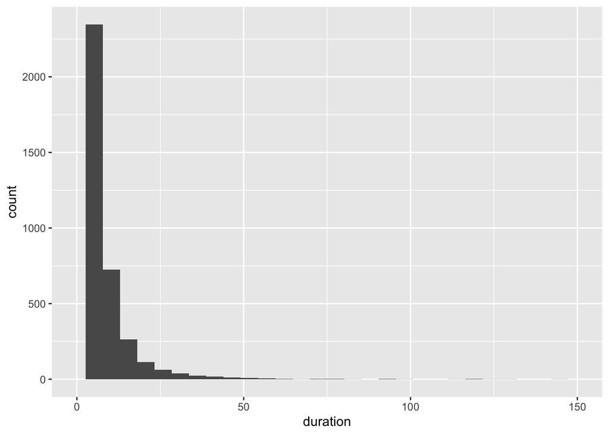

```r
bikes$duration <- as.numeric(bikes$duration)

ggplot(bikes, aes(x = duration)) + geom_histogram() + xlim(0, 150)
```

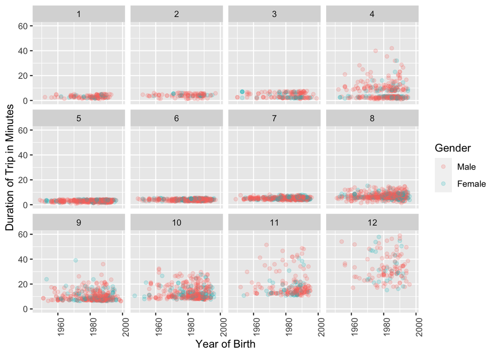

```r
ggplot(bikes_nyc, aes(x = birth_year, y = bikes$duration, color = gender)) +
  geom_point(alpha = 0.2) + scale_x_continuous() + scale_y_time() +
  ylim(0, 60) + theme(axis.text.x = element_text(angle = 90)) +
  facet_wrap(~month(bikes_nyc$start_time)) +
  labs(x = "Year of Birth", y = "Duration of Trip in Minutes", color =
         "Gender")
```

#Exercise 2 The goal of this exercise is again a visualisation of certain information we can obtain through the nyc_bikes data set.

Here, you can practice how to set up a tsibble. Because we use the same data set as before, you do not need to check and tidy the data again.

```r
nycbikes_ts <- nyc_bikes %>%
   as_tsibble(key = bike_id, index = start_time, regular = FALSE)
```

But we want to transform the temporal data a bit differently this time around - measuring the duration of trips in minutes without decimals and compute a variable that contains the start hour for each rented bike.

```r
nyc2 <- nycbikes_ts %>% mutate(duration_mins = as.numeric(
   round(difftime(stop_time, start_time, units = "mins"),0)))

#index by start_hour
nyc2 %>%
   index_by(start_hour = floor_date(start_time, unit = "1 hour"))
```

```
## # A tsibble: 4,268 x 14 [!] <America/New_York>
## # Key:       bike_id [10]
## # Groups:    @ start_hour [2,605]
##    bike_id start_time          stop_time           start_station start_lat
##    <fct>   <dttm>              <dttm>              <fct>             <dbl>
##  1 26301   2018-02-26 19:11:03 2018-02-26 19:15:40 3186               40.7
##  2 26301   2018-02-27 07:52:49 2018-02-27 07:58:13 3203               40.7
##  3 26301   2018-02-27 12:03:27 2018-02-27 12:04:54 3202               40.7
##  4 26301   2018-02-27 13:53:51 2018-02-27 14:21:04 3638               40.7
##  5 26301   2018-02-27 14:30:42 2018-02-27 14:33:11 3638               40.7
##  6 26301   2018-02-27 16:31:04 2018-02-27 16:33:27 3187               40.7
##  7 26301   2018-02-27 17:37:12 2018-02-27 17:40:49 3638               40.7
##  8 26301   2018-02-27 17:49:10 2018-02-27 17:55:03 3639               40.7
##  9 26301   2018-02-27 18:21:57 2018-02-27 18:25:18 3202               40.7
## 10 26301   2018-02-27 22:08:55 2018-02-27 22:28:42 3638               40.7
## # … with 4,258 more rows, and 9 more variables: start_long <dbl>,
## #   end_station <fct>, end_lat <dbl>, end_long <dbl>, type <fct>,
## #   birth_year <dbl>, gender <fct>, duration_mins <dbl>, start_hour <dttm>
```

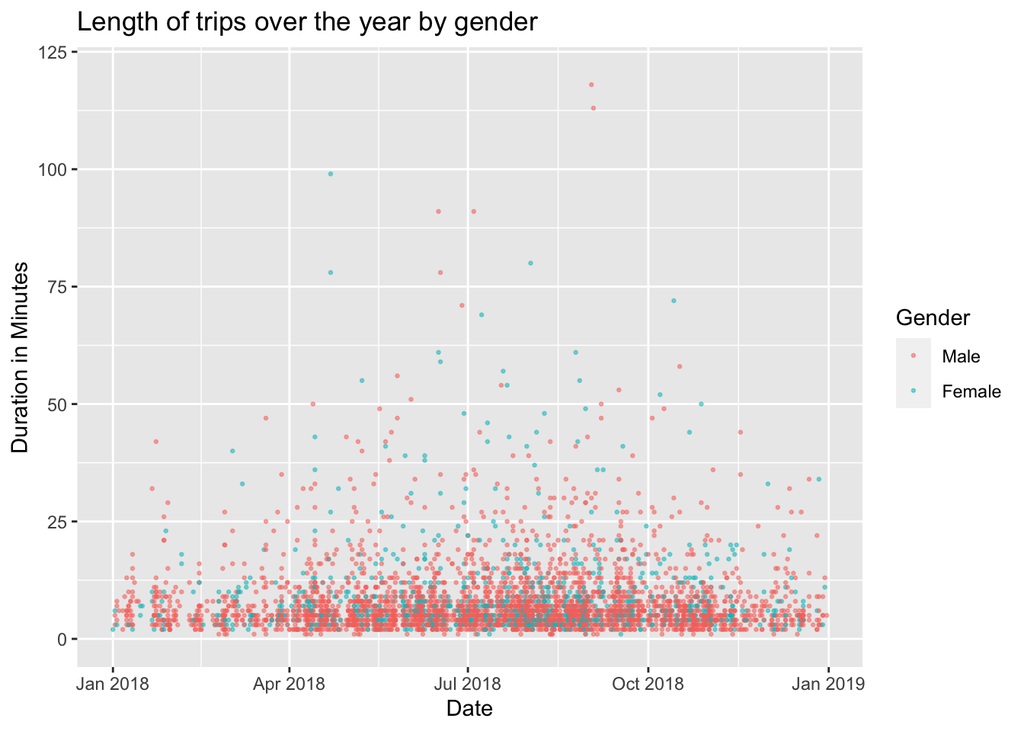

```r
#extract general start hour and date from more specific timestamp data
nyc3 <- nyc2 %>%
   mutate(start_hour = floor_date(start_time, unit = "1 hour")) %>%
   mutate(date = as_date(start_hour), time = hour(start_hour)) %>%
   filter(gender != "Unknown")

#differentiate again by gender
nyc3 %>% ggplot(aes(x = date, y = duration_mins, colour = gender)) +
   geom_point(size = 0.5, alpha = 0.5) + ylim(0, 120) + labs(x = "Date",
              y = "Duration in Minutes", color = "Gender", title =
                "Length of trips over the year by gender")
```

Now we plot again. This time, please visualise the duration of rentals noting the different kind of users, customers who have a subscription and one-time users.

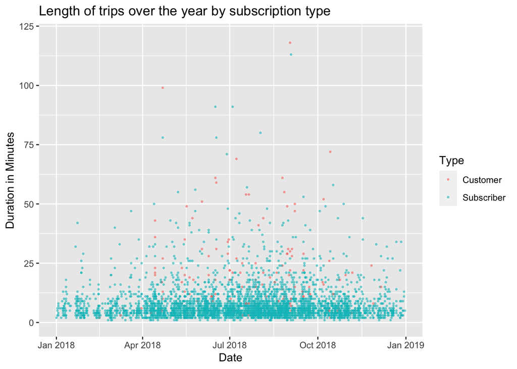

```r
nyc3 %>% ggplot(aes(x = date, y = duration_mins, colour = type)) +
   geom_point(size = 0.5, alpha = 0.5) + ylim(0, 120) + labs(x = "Date",
              y = "Duration in Minutes", color = "Type", title =
                "Length of trips over the year by subscription type")
```

Also very interesting (and great to do with tsibble :-)) is to look at the rate of people renting bikes over the year.

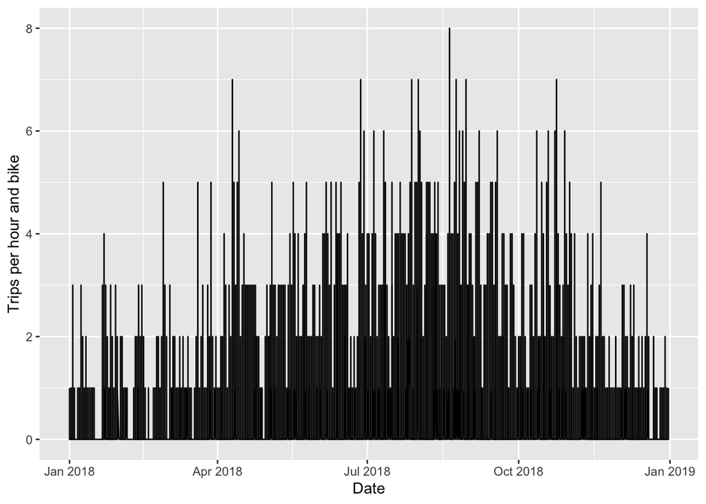

```r
#summarize total number of trips by hour, using the start hour as index
hourly_trips <- nyc2 %>%
   index_by(start_hour = floor_date(start_time, unit = "1 hour")) %>%
   summarise(ntrips = n())

#fill any gaps, and add column for date
full_trips <- hourly_trips %>%
   fill_gaps(ntrips = 0L) %>%
   mutate(date = as_date(start_hour), time = hour(start_hour),
          month = month(date))

#visualise trips per hour by date over the course of the year
full_trips %>% ggplot(aes(x = date, y = ntrips)) + geom_line() +
  labs(x = "Date", y = "Trips per hour and bike")
```

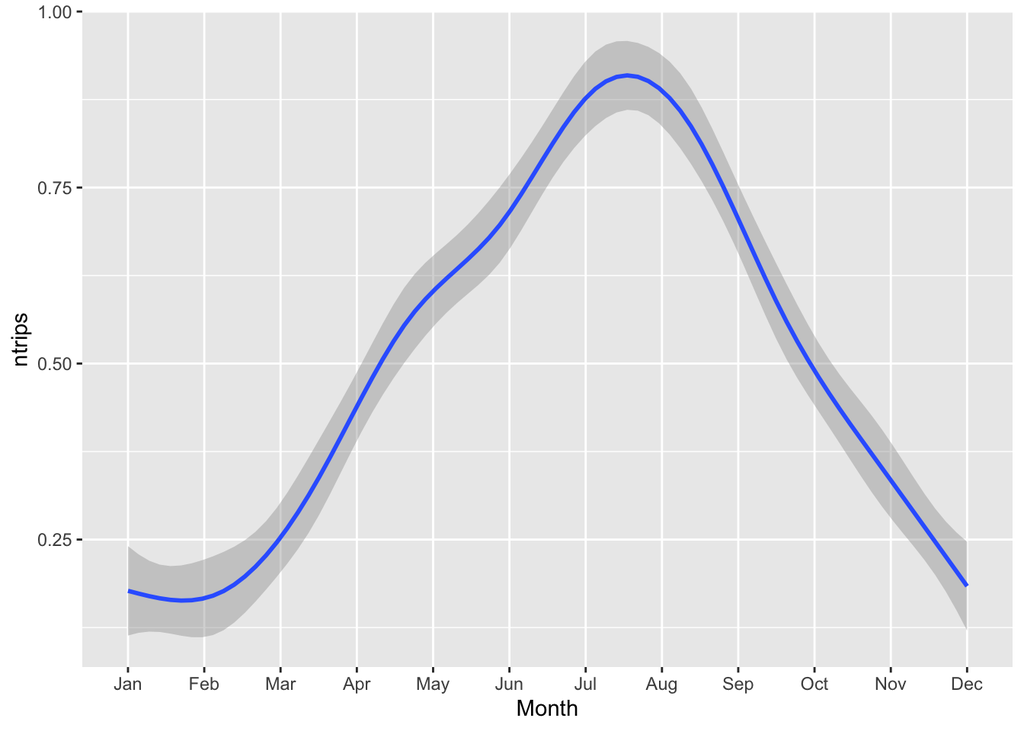

```r
#plotting a smoothing line, we find that the number of trips are highly
#correlated with the seasons, declining as the weather gets colder.
full_trips %>% ggplot(aes(x = month, y = ntrips)) + geom_smooth() +
   scale_x_discrete(limits = month.abb) + labs(x = "Month")
```